# Retail Store (sample superstore)- Exploratory Data Analysis

# Team Members (Team-8)

1.Anirudh Chinan Edathil

2.Balraj Singh Ojla

3.Harshkumar Dineshbhai Patel

4.Muzafer Hussain

5.Sai Abhiram Gundala Parthasarathy

# Objective

The project aims to carryout an exploratory data analysis of retail store in order to take responsibility as a analytical manager and identify and improve the weak areas and product categories in terms of sales and profit. To find the areas or products with high sales and profit to make better decision for future business strategies.

# Data Source

https://www.kaggle.com/bravehart101/sample-supermarket-dataset/code

The dataset was downloaded from Kaggle and it is renamed to "retailstore".

Variables:

Ship Mode- is the method of shipping the physical goods and products to the intended customers.

Segment- specifies the customer segment or marketing groups according to their interests and demographics.

Country- is all in the United States of America (USA).

City- refers to the cities in USA.

State- is made up of the states in USA.

Region- indicates the geographic position in the USA continent.

Category- consists of the named groups of similar and defined physical products.

Sub-Category- lists the subdivisions with respect to a given category.

Sales- are the monetary value of transactions between the Superstore and its customers of physical goods in American Dollars (USD$) measurements.

Quantity- records the number of such products in each sales transaction.

Discount- states the percentage of monetary deduction from the usual product price, and 'Profit' is the financial gains in USD\$ from each sales transaction.

Profit- is the financial gains in USD from each transaction.

# Packages

```python
#Importing the libraries
import pandas as pd
import numpy as np
import seaborn as sns
import matplotlib.pyplot as plt
import warnings
warnings.filterwarnings('ignore')
```

# Importing Dataset

```python
#Loading the datatset
retailstore=pd.read_csv(r"C:\Users\ABHI\OneDrive\Desktop\classes\1st Sem\DAB 103\RetailStore.csv")
```

```python
#viewing head of the dataset
retailstore.head()
```

|  | Ship Mode | Segment | Country | City | State | Postal Code | Region | Category | Sub-Category | Sales | Quantity | Discount | Profit |
| --- | --- | --- | --- | --- | --- | --- | --- | --- | --- | --- | --- | --- | --- |
| 0 | Second Class | Consumer | United States | Henderson | Kentucky | 42420 | South | Furniture | Bookcases | 261.9600 | 2 | 0.00 | 41.9136 |
| 1 | Second Class | Consumer | United States | Henderson | Kentucky | 42420 | South | Furniture | Chairs | 731.9400 | 3 | 0.00 | 219.5820 |
| 2 | Second Class | Corporate | United States | Los Angeles | California | 90036 | West | Office Supplies | Labels | 14.6200 | 2 | 0.00 | 6.8714 |
| 3 | Standard Class | Consumer | United States | Fort Lauderdale | Florida | 33311 | South | Furniture | Tables | 957.5775 | 5 | 0.45 | -383.0310 |
| 4 | Standard Class | Consumer | United States | Fort Lauderdale | Florida | 33311 | South | Office Supplies | Storage | 22.3680 | 2 | 0.20 | 2.5164 |

```python
#Viewing tail of the dataset
retailstore.tail()
```

[output not shown]

# Data analysis and cleaning

```python
#checking the number of columns and rows of dataset
retailstore.shape
```

```
(9994, 13)
```

```python
#Summary of dataset
retailstore.info()
```

```
<class 'pandas.core.frame.DataFrame'>
RangeIndex: 9994 entries, 0 to 9993
Data columns (total 13 columns):
 #   Column        Non-Null Count  Dtype
---  ------        --------------  -----
 0   Ship Mode     9994 non-null   object
 1   Segment       9994 non-null   object
 2   Country       9994 non-null   object
 3   City          9994 non-null   object
 4   State         9994 non-null   object
 5   Postal Code   9994 non-null   int64
 6   Region        9994 non-null   object
 7   Category      9994 non-null   object
 8   Sub-Category  9994 non-null   object
 9   Sales         9994 non-null   float64
 10  Quantity      9994 non-null   int64
 11  Discount      9994 non-null   float64
 12  Profit        9994 non-null   float64
dtypes: float64(3), int64(2), object(8)
memory usage: 1015.1+ KB
```

```python
#missing values in dataset
retailstore.isnull().sum()
```

```
Ship Mode       0
Segment         0
Country         0
City            0
State           0
Postal Code     0
Region          0
Category        0
Sub-Category    0
Sales           0
Quantity        0
Discount        0
Profit          0
dtype: int64
```

We can see that there are no missing values in the dataset

```python
#Checking Datatypes of Columns
retailstore.dtypes
```

```
Ship Mode        object
Segment          object
Country          object
City             object
State            object
Postal Code       int64
Region           object
Category         object
Sub-Category     object
Sales           float64
Quantity          int64
Discount        float64
Profit          float64
dtype: object
```

```python
#Checking Statistics of Dataset
retailstore.describe()
```

|  | Postal Code | Sales | Quantity | Discount | Profit |
| --- | --- | --- | --- | --- | --- |
| count | 9994.000000 | 9994.000000 | 9994.000000 | 9994.000000 | 9994.000000 |
| mean | 55190.379428 | 229.858001 | 3.789574 | 0.156203 | 28.656896 |
| std | 32063.693350 | 623.245101 | 2.225110 | 0.206452 | 234.260108 |
| min | 1040.000000 | 0.444000 | 1.000000 | 0.000000 | -6599.978000 |
| 25% | 23223.000000 | 17.280000 | 2.000000 | 0.000000 | 1.728750 |
| 50% | 56430.500000 | 54.490000 | 3.000000 | 0.200000 | 8.666500 |
| 75% | 90008.000000 | 209.940000 | 5.000000 | 0.200000 | 29.364000 |
| max | 99301.000000 | 22638.480000 | 14.000000 | 0.800000 | 8399.976000 |

```python
#Finding unique values in columns
retailstore.nunique()
```

```
Ship Mode          4
Segment            3
Country            1
City             531
State             49
Postal Code      631
Region             4
Category           3
Sub-Category      17
Sales           5825
Quantity          14
Discount          12
Profit          7287
dtype: int64
```

Country has only 1 unique value (United States), It has no role in generating patterns and therefore we are dropping it.

```python
#Removing unwanted Columns
c = ['Postal Code','Country']
retailstore =retailstore.drop(columns=c, axis=1)
```

There is no much importance or role of Postal Code variable with respect to the data plots and hence we are removing the column.

```python
retailstore.describe()
```

|  | Sales | Quantity | Discount | Profit |
| --- | --- | --- | --- | --- |
| count | 9994.000000 | 9994.000000 | 9994.000000 | 9994.000000 |
| mean | 229.858001 | 3.789574 | 0.156203 | 28.656896 |
| std | 623.245101 | 2.225110 | 0.206452 | 234.260108 |
| min | 0.444000 | 1.000000 | 0.000000 | -6599.978000 |
| 25% | 17.280000 | 2.000000 | 0.000000 | 1.728750 |
| 50% | 54.490000 | 3.000000 | 0.200000 | 8.666500 |
| 75% | 209.940000 | 5.000000 | 0.200000 | 29.364000 |
| max | 22638.480000 | 14.000000 | 0.800000 | 8399.976000 |

```python
#Viewing the head of the dataset to check if the columns are deleted
retailstore.head()
```

|  | Ship Mode | Segment | City | State | Region | Category | Sub-Category | Sales | Quantity | Discount | Profit |
| --- | --- | --- | --- | --- | --- | --- | --- | --- | --- | --- | --- |
| 0 | Second Class | Consumer | Henderson | Kentucky | South | Furniture | Bookcases | 261.9600 | 2 | 0.00 | 41.9136 |
| 1 | Second Class | Consumer | Henderson | Kentucky | South | Furniture | Chairs | 731.9400 | 3 | 0.00 | 219.5820 |
| 2 | Second Class | Corporate | Los Angeles | California | West | Office Supplies | Labels | 14.6200 | 2 | 0.00 | 6.8714 |
| 3 | Standard Class | Consumer | Fort Lauderdale | Florida | South | Furniture | Tables | 957.5775 | 5 | 0.45 | -383.0310 |
| 4 | Standard Class | Consumer | Fort Lauderdale | Florida | South | Office Supplies | Storage | 22.3680 | 2 | 0.20 | 2.5164 |

From above table, we can see that Postal code and Country columns are removed.

```python
#Covariance of the dataset
retailstore.cov()
```

|  | Sales | Quantity | Discount | Profit |
| --- | --- | --- | --- | --- |
| Sales | 388434.455308 | 278.459923 | -3.627228 | 69944.096586 |
| Quantity | 278.459923 | 4.951113 | 0.003961 | 34.534769 |
| Discount | -3.627228 | 0.003961 | 0.042622 | -10.615173 |
| Profit | 69944.096586 | 34.534769 | -10.615173 | 54877.798055 |

```python
#correlation of dataset
retailstore.corr()
```

|  | Sales | Quantity | Discount | Profit |
| --- | --- | --- | --- | --- |
| Sales | 1.000000 | 0.200795 | -0.028190 | 0.479064 |
| Quantity | 0.200795 | 1.000000 | 0.008623 | 0.066253 |
| Discount | -0.028190 | 0.008623 | 1.000000 | -0.219487 |
| Profit | 0.479064 | 0.066253 | -0.219487 | 1.000000 |

```
<function matplotlib.pyplot.show(close=None, block=None)>
```

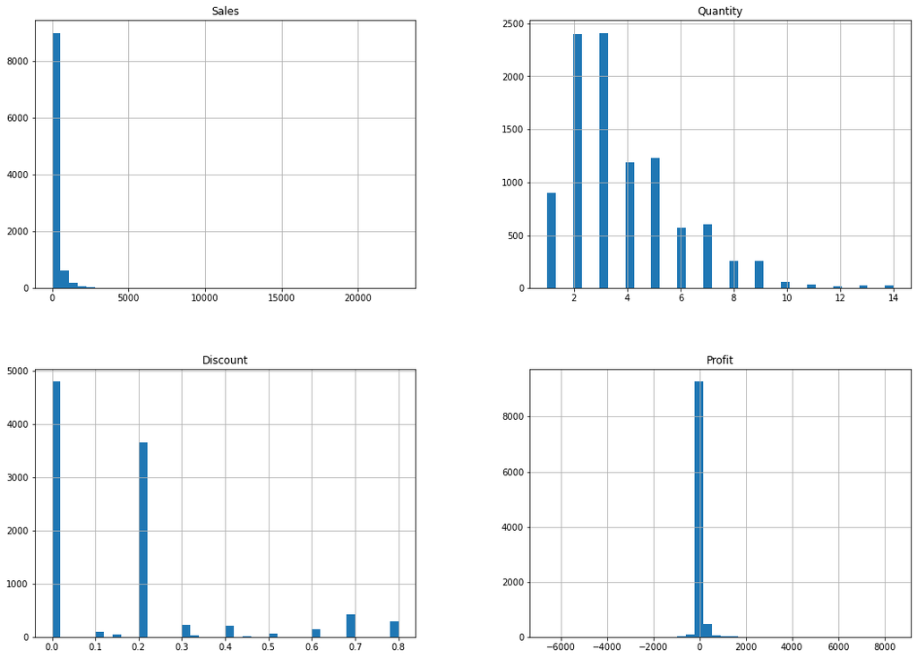

```python
#Finding Outliers
retailstore.hist(bins=40,figsize=(18,13))
plt.show
```

The values approximately lie within an expected range and hence there is no need to consider any outliers

# Categorical variable analysis

```
Standard Class    5968
Second Class      1945
First Class       1538
Same Day           543
Name: Ship Mode, dtype: int64
```

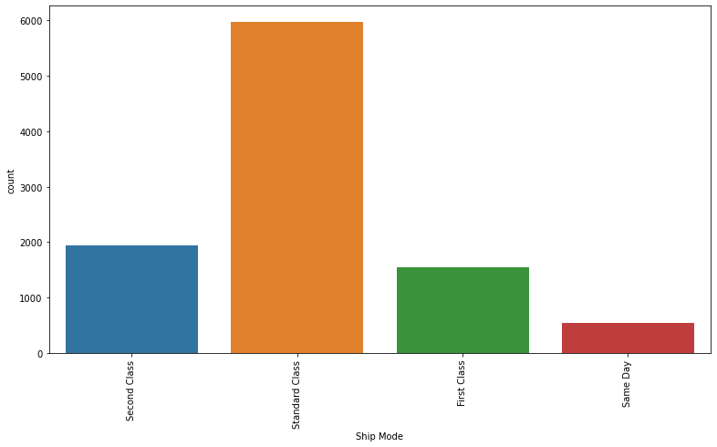

```python
# Counting the values for each Ship Mode and plotting for the same
print(retailstore['Ship Mode'].value_counts())
plt.figure(figsize=(13,7))
sns.countplot(x=retailstore['Ship Mode'])
plt.xticks(rotation=90)
plt.show()
```

Standard class has the highest count (5968) which means that it is opted for the maximum number of times for shipping products.

```
Binders        1523
Paper          1370
Furnishings     957
Phones          889
Storage         846
Art             796
Accessories     775
Chairs          617
Appliances      466
Labels          364
Tables          319
Envelopes       254
Bookcases       228
Fasteners       217
Supplies        190
Machines        115
Copiers          68
Name: Sub-Category, dtype: int64
```

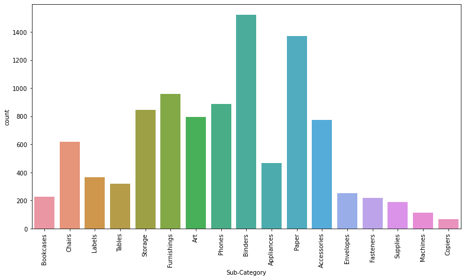

```python
# Counting the values for each sub-category and plotting for the same
print(retailstore['Sub-Category'].value_counts())
plt.figure(figsize=(13,7))
sns.countplot(x=retailstore['Sub-Category'])
plt.xticks(rotation=90)
plt.show()
```

From the above plot, It is evident that Binders have the highest count.

# Numerical variable analysis

```python
#Analysis of quantity variable
retailstore['Quantity'].describe()
```

```
count    9994.000000
mean        3.789574
std         2.225110
min         1.000000
25%         2.000000
50%         3.000000
75%         5.000000
max        14.000000
Name: Quantity, dtype: float64
```

```
3     2409
2     2402
5     1230
4     1191
1      899
7      606
6      572
9      258
8      257
10      57
11      34
14      29
13      27
12      23
Name: Quantity, dtype: int64
```

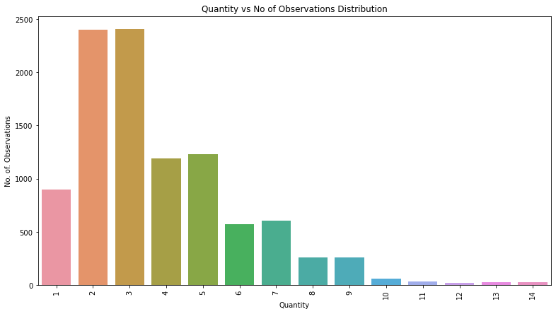

```python
print(retailstore['Quantity'].value_counts())
plt.figure(figsize=(13,7))
sns.countplot(x=retailstore['Quantity'])
plt.xticks(rotation=90)
plt.xlabel("Quantity")
plt.ylabel("No. of. Observations")
plt.title('Quantity vs No of Observations Distribution')
plt.show()
```

Bar plot between quantity and number of observations where quantity of products with values 2 & 3 account for highest observations.

# Creating Heatmap of the dataset

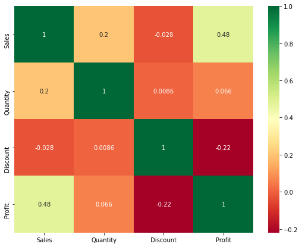

```python
#correlation between numerical columns using the Heatmap
plt.figure(figsize=(9,7))
correlation=retailstore.corr()
sns.heatmap(correlation,annot=True, cmap='RdYlGn')
plt.show()
```

Also, we can see that there is negative correlation(-0.22) between discount and profit. Hence profit can seen decreasing if discount increases.

# Analysing two Numerical Values

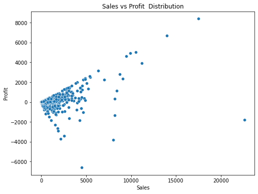

```python
#lineplot between Profit & sales
plt.figure(figsize=(8,6))
sns.scatterplot(x='Sales',y='Profit',data=retailstore)
plt.xlabel("Sales")
plt.ylabel("Profit")
plt.title('Sales vs Profit  Distribution')
plt.show()
```

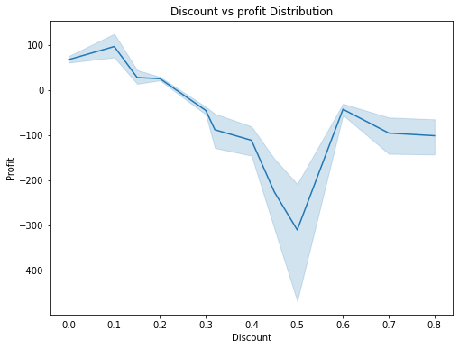

```python
#lineplot between Profit & Discount
plt.figure(figsize=(8,6))
sns.lineplot(x='Discount',y='Profit',data=retailstore)
plt.xlabel("Discount")
plt.ylabel("Profit")
plt.title('Discount vs profit Distribution')
plt.show()
```

From above Lineplot, the trend of profit with respect to discount can be observed i.e profit decreases as discount increases.

# Analysing Numerical and categorical variable

```python
#calculating the statewise profit
profit_sum=retailstore.groupby("State")["Profit"].sum()
profit_sum
```

```
State
Alabama                  5786.8253
Arizona                 -3427.9246
Arkansas                 4008.6871
California              76381.3871
Colorado                -6527.8579
Connecticut              3511.4918
Delaware                 9977.3748
District of Columbia     1059.5893
Florida                 -3399.3017
Georgia                 16250.0433
Idaho                     826.7231
Illinois               -12607.8870
Indiana                 18382.9363
Iowa                     1183.8119
Kansas                    836.4435
Kentucky                11199.6966
Louisiana                2196.1023
Maine                     454.4862
Maryland                 7031.1788
Massachusetts            6785.5016
Michigan                24463.1876
Minnesota               10823.1874
Mississippi              3172.9762
Missouri                 6436.2105
Montana                  1833.3285
Nebraska                 2037.0942
Nevada                   3316.7659
New Hampshire            1706.5028
New Jersey               9772.9138
New Mexico               1157.1161
New York                74038.5486
North Carolina          -7490.9122
North Dakota              230.1497
Ohio                   -16971.3766
Oklahoma                 4853.9560
Oregon                  -1190.4705
Pennsylvania           -15559.9603
Rhode Island             7285.6293
South Carolina           1769.0566
South Dakota              394.8283
Tennessee               -5341.6936
Texas                  -25729.3563
Utah                     2546.5335
Vermont                  2244.9783
Virginia                18597.9504
Washington              33402.6517
West Virginia             185.9216
Wisconsin                8401.8004
Wyoming                   100.1960
Name: Profit, dtype: float64
```

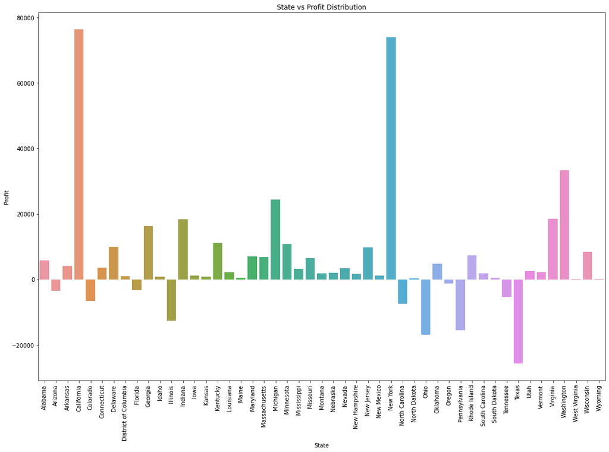

```python
#Barplot for state wise profit
plt.figure(figsize=(18,12))
sns.barplot(x=profit_sum.index, y=profit_sum.values)
plt.ylabel("Profit")
plt.xticks(rotation=90)
plt.xlabel("State")
plt.ylabel("Profit")
plt.title('State vs Profit Distribution')
plt.show()
```

From the plot, we can see that California has the highest profit followed by New York, Washngton and Michigan while Texas holds for the lowest profit followed by Ohio, Pennsylvania and Illinois.